# Common LIMS design

## About this document

This document contains the high level diagrams for how Common LIMS is constructed.

First, we focus on the use cases in the web UI and how it interacts with the backend (rest API). Side effects, in terms of data created, is shown, but other details might be omitted until later in the documentation.

All of the diagrams are maintained in draw.io and the source can be fetched from ./diagrams/commonlims.drawio

## Notation

Names written like `name1 => name2` are to be renamed to that second name in the source code.

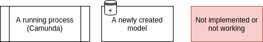

## Repositories

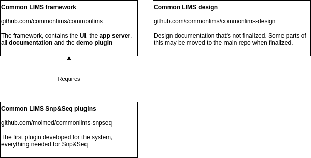

## Terms

- Substance: A generic word for a sample, pool, index tag etc. All substances are also Locatable
- Container: A container can hold Locatables, i.e. Substances or other Containers.
- Locatable: Anything that can be put into a Container (both Containers and Substances are Locatable)
- Sample: A sample probably means what one would expect in a lab, an individual item that's being researched. Samples are instances of Substances.

## Actors

### Admin

Admins setup the system and have all the rights all other users have.

### Coordinator

A lab coordinator takes care of creating projects, contacts etc. They may have rights to break the general workflow.

### Research engineer (RE)

Research engineers generally work within a well defined workflow in order to make their job easier and limit chances of errors.

## Use cases

### About

Unless otherwise indicated, these are all started in the web UI

Coordinator can import samples into the system, where the logic is based on loaded plugins.

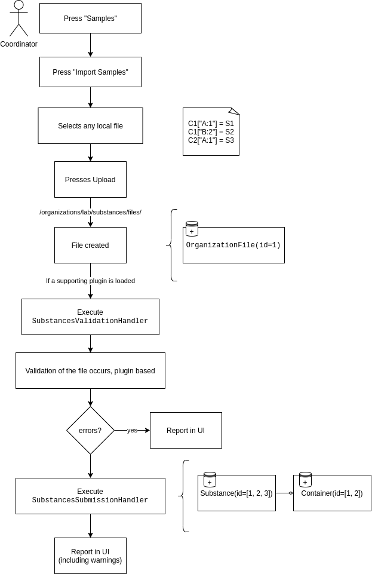

### UC2: Download example sample submission file

Coordinator can create a demo example file, one that the plugin will accept in UC1.

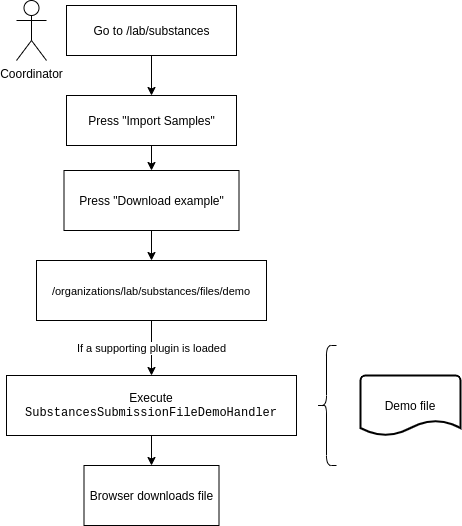

### UC3: Create example data (terminal)

Defining custom example data for a plugin is as simple as implementing a CreateExampleDataHandler.

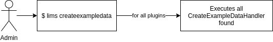

### UC4: Coordinator can assign to workflow

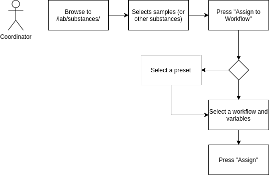

### UC5: Start work

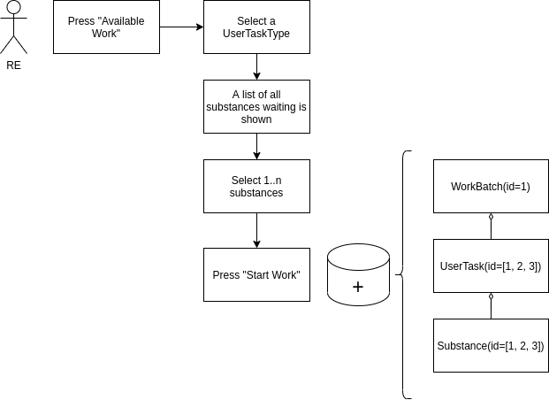